# Effects of protection status on California spiny lobster (*Panulirus interruptus*) size and abundance in the Santa Barbara Channel

Kazia Mermel

11/15/2019

### Introduction

The California Spiny Lobster (*Panulirus interruptus*) can be found along the west coast of North America from Monterey Bay, California down to Baja California, Mexico. It is a commercially and ecologically important species. In the 2014-2015 fishing season, commercial vessels landed about 430.9 metric tons of spiny lobster along the west coast. Spiny lobsters add about 33 to 40 million dollars annually to the California economy. They also function as a key predator in kelp forests along the coast of Southern California (CA Lobster FMP).

A few changes in the past ten years have led the California Department of Fish and Wildlife to evaluate the management of the fishery. First, a series of Marine Protected Areas (MPA’s) were instituted along the Southern California coast in 2012 in accordance with the Marine Life Management Act (MLMA). In addition, the value per pound of lobsters has increased in the past few years, as have commercial fishing pressures (CA Lobster FMP).

Here, we evaluate how size and abundance has varied between protected and unprotected sites along Santa Barbara Channel between 2012 and 2018.

### Data and Methods

Divers collected observations of spiny lobster abundance and size at five sites along the Santa Barbara Channel between 2012 and 2018 as part of the Santa Barbara Channel Long-Term Ecological Research effort. Two of those sites, Isla Vista (IVEE) and Naples (NAPL), are located within MPAs. Isla Vista and Naples were both established as MPAs at the start of 2012. The other three sites, Arroyo Quemado (AQUE), Carpinteria (CARP), and Mohawk (MOHK), are not protected. Observations were collected every two to four weeks at the end of summer each year so as to precede the start of the fishing season.

### Results

#### Results A: How has lobster abundance changed over time at each site?

Total spiny lobster abundance across sites has increased between 2012 and 2018 (Figure 1). Abundance at the Carpinteria and Isla Vista sites in particular have increased, although lobster levels declined in 2018 at the Carpinteria site. Mohawk and Naples have shown very modest increases in abundance. Abundance at Arroyo Quemado has remained nearly constant.

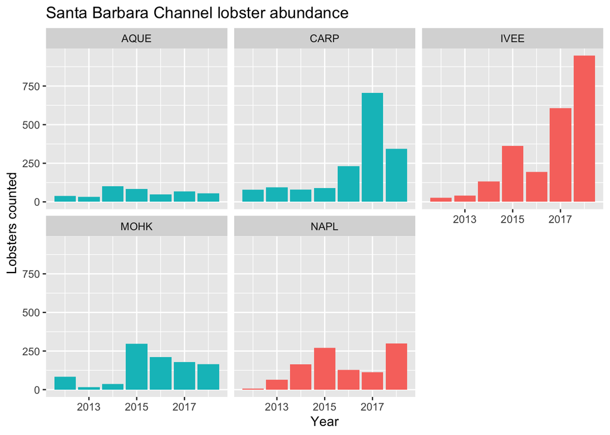

**Figure 1**: Total annual lobster abundance at each of five sites in the Santa Barbara Channel between 2012 and 2018. Two of these collection sites, Isla Vista (IVEE) and Naples (NAPL), are located within Marine Protected Areas. Three, Arroyo Quemado (AQUE), Mohawk (MOHK), and Carpinteria (CARP), are outside.

#### Results B: How were lobster sizes distributed at each site in 2012 and 2018?

Modal lobster size increased in the two protected sites, Isla Vista and Naples, from 2012 to 2018 (Figure 2). There was not a clear change in modal size for lobsters in the unprotected sites, Arroyo Quemado, Carpinteria, and Mohawk, although variation in lobster size seems to have declined between 2012 and 2018 at the Carpinteria site (Figure 2).

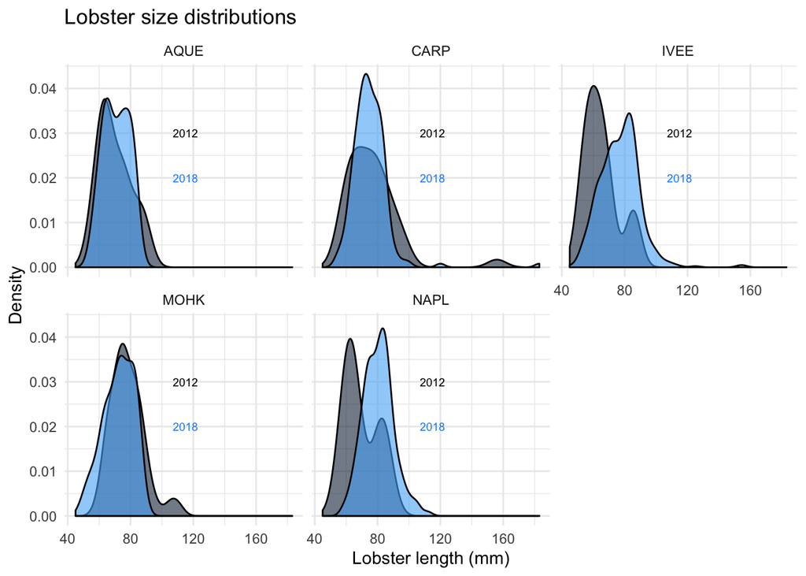

**Figure 2**: Size distributions for lobsters at the five sites in 2012 and 2018. Isla Vista (IVEE) and Naples (NAPL) are within Marine Protected Areas; Arroyo Quemado (AQUE), Carpinteria (CARP), and Mohawk (MOHK) are not protected.

#### Results C: How did mean lobster size change between 2012 and 2018 at protected and unprotected sites?

In fact, mean lobster size within MPAs increased between 2012 (65.69 mm) and 2018 (77.79 mm) by over 12 mm (t(32.5) = -4.69, *p* < 0.01). Meanwhile, mean lobster size at sites outside the MPAs showed no significant change between 2012 and 2018 (t(296.01) = 1.33, *p* > 0.01)

**Table 1**: Summary statistics for spiny lobster size in 2012 and 2018, within and outside of Marine Protected Areas.

| Lobster size metrics Status | Lobster size metrics Year | Lobster size metrics Mean (mm) | Lobster size metrics Standard deviation (mm) | Lobster size metrics Sample count |
| --- | --- | --- | --- | --- |
| MPA | 2012 | 65.68750 | 10.75000 | 16 |
| MPA | 2018 | 77.79133 | 12.10836 | 623 |
| non-MPA | 2012 | 75.87000 | 13.76400 | 100 |
| non-MPA | 2018 | 73.91429 | 11.22656 | 280 |

### Summary

- When MPAs were designated in the Santa Barbara Channel in 2012, average California spiny lobster (*Panulirus interruptus*) length was greater outside of MPAs than inside them (Table 1)
- Average length of spiny lobsters in MPAs increased between 2012 and 2018, while lobster length remained on average unchanged at non-MPA sites (Table 1)
- In 2018, lobster lengths were on average greater within MPAs than outside of them (Table 1)

### References

“California Spiny Lobster Fishery Management Plan.” California Department of Fish and Wildlife Marine Region, 2016, https://www.wildlife.ca.gov/Conservation/Marine/Lobster-FMP.

“Santa Barbara Coastal Long-Term Ecological Research.” Santa Barbara Coastal LTER, 2019, https://sbclter.msi.ucsb.edu/.